# Implementing Consonance

Andrea Lanz

11/26/2018

## Consonace

- Which notes sound good together?
- Notes with frequencies with simple ratios
- The different scales are examples of notes with consonant sounds

The purpose of this file is to implement more consonant notes in my simulation of music.

The following data was found at the following source:

- Suits, B. H., Physics of Music - Notes. Physics Department, Michigan Technological University. http://pages.mtu.edu/~suits/notefreqs.html

Read in notes data:

```r
full_notes <- read.csv(here("data", "note_freq.csv")) #includes all parts of dataframe
full_notes
```

```
##     X      Note Frequency..Hz. Wavelength..cm.
## 1   1        A0          27.50         1254.55
## 2   2  A#0/Bb0           29.14         1184.13
## 3   3        B0          30.87         1117.67
## 4   4        C1          32.70         1054.94
## 5   5  C#1/Db1           34.65          995.73
## 6   6        D1          36.71          939.85
## 7   7  D#1/Eb1           38.89          887.10
## 8   8        E1          41.20          837.31
## 9   9        F1          43.65          790.31
## 10 10  F#1/Gb1           46.25          745.96
## 11 11        G1          49.00          704.09
## 12 12  G#1/Ab1           51.91          664.57
## 13 13        A1          55.00          627.27
## 14 14  A#1/Bb1           58.27          592.07
```

[output cut: 74 more lines]

```r
notes <- (read.csv(here("data", "note_freq.csv")))$Frequency..Hz. #just the frequencies
```

The following will assign the sequence of numbers that corresponds to all octaves of a specific note in the frequency data.

```r
note_A <- seq(from = 1, to = 85, by = 12)
note_B <- seq(from = 3, to = 87, by = 12)
note_C <- seq(from = 4, to = 88, by = 12)
note_D <- seq(from = 6, to = 78, by = 12)
note_E <- seq(from = 8, to = 80, by = 12)
note_F <- seq(from = 9, to = 81, by = 12)
note_G <- seq(from = 11, to = 83, by = 12)

note_Asharp <- seq(from = 2, to = 86, by = 12)
note_Csharp <- seq(from = 5, to = 77, by = 12)
note_Dsharp <- seq(from = 4, to = 88, by = 12)
note_Fsharp <- seq(from = 4, to = 88, by = 12)
note_Gsharp <- seq(from = 4, to = 88, by = 12)
```

Create a transition matrix for the C major scale (C,D,E,F,G,A):

View the C Major note frequencies:

```r
C_major <- c(note_C,note_D, note_E, note_F, note_G, note_A)
C_major_full <- full_notes[C_major, ]
C_major_full
```

```
##     X Note Frequency..Hz. Wavelength..cm.
## 4   4   C1          32.70         1054.94
## 16 16   C2          65.41          527.47
## 28 28   C3         130.81          263.74
## 40 40   C4         261.63          131.87
## 52 52   C5         523.25           65.93
## 64 64   C6        1046.50           32.97
## 76 76   C7        2093.00           16.48
## 88 88   C8        4186.01            8.24
## 6   6   D1          36.71          939.85
## 18 18   D2          73.42          469.92
## 30 30   D3         146.83          234.96
## 42 42   D4         293.66          117.48
## 54 54   D5         587.33           58.74
## 66 66   D6        1174.66           29.37
```

[output cut: 30 more lines]

Note that middle C is the fourth element in ‘C_major’, and each note has 7 octaves, except for C and A which have 8.

Create a transition matrix that only considers notes in the C major scale:

```r
P1 <- matrix(numeric(88), nrow = 88, ncol = 88) #create a zero matrix
P1[C_major, C_major] = 1/length(C_major)
rowSums(P1)
```

```
##  [1] 1 0 0 1 0 1 0 1 1 0 1 0 1 0 0 1 0 1 0 1 1 0 1 0 1 0 0 1 0 1 0 1 1 0 1
## [36] 0 1 0 0 1 0 1 0 1 1 0 1 0 1 0 0 1 0 1 0 1 1 0 1 0 1 0 0 1 0 1 0 1 1 0
## [71] 1 0 1 0 0 1 0 1 0 1 1 0 1 0 1 0 0 1
```

Note that the row sums for the matrix are all 1 for the notes that we are considering, which is what is expected for a Markov transition matrix.

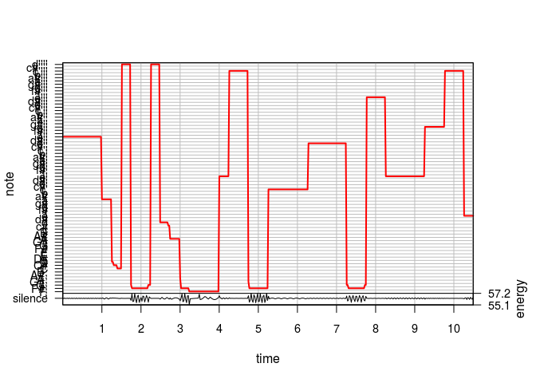

```r
sample1 <- generate_markov_sample(5,P1)
generate_lilypond(sample1, 5, file_name = here("results", "implement_consonance_ex1.ly"))
```

This song sounds much more pleasant to listen to than notes randomly sampled from all 88.

Note that this process is equivalent to sampling randomly from C major notes, since only C major notes have nonzero probability, with equal probability. This example song can be found in the ‘results’ directory called ‘implement_consonance_ex1.ly’.

Next, the C_major scale will be sampled from, but the probability of getting a note in a similar octave is greater than of a lower or higher octave.

Gather the notes from each octave skipping 0 and 8:

```r
sorted_C_major <- sort(C_major) #sort the notes
octaves <- split(sorted_C_major[2:43], ceiling(seq_along(sorted_C_major[2:43])/6))
octaves
```

```
## $`1`
## [1]  4  6  8  9 11 13
##
## $`2`
## [1] 16 18 20 21 23 25
##
## $`3`
## [1] 28 30 32 33 35 37
##
## $`4`
## [1] 40 42 44 45 47 49
##
## $`5`
## [1] 52 54 56 57 59 61
##
## $`6`
## [1] 64 66 68 69 71 73
##
## $`7`
## [1] 76 78 80 81 83 85
```

Create the transition matrix where notes in the same octave have a higher probability of being selected. **Note** I implemented the following code in C++, and the documentation can be found in the ‘doc’ directory titled Timing_Experiments.Rmd*

```r
p1 <- 1 #weight for sampling from a different octave
p2 <- 2 #weight for sampling from the same octave
P2 <- matrix(numeric(88), nrow = 88, ncol = 88)
for (i in 1:7){
   for(j in 1:7){
      if(j != i){
         P2[unlist(octaves[i]), unlist(octaves[j])] <- p1/(p1*36 + p2*6) #ensures the rows sum to one
      }else{
         P2[unlist(octaves[i]), unlist(octaves[i])] <- p2/(p1*36 + p2*6)
      }
   }
}
```

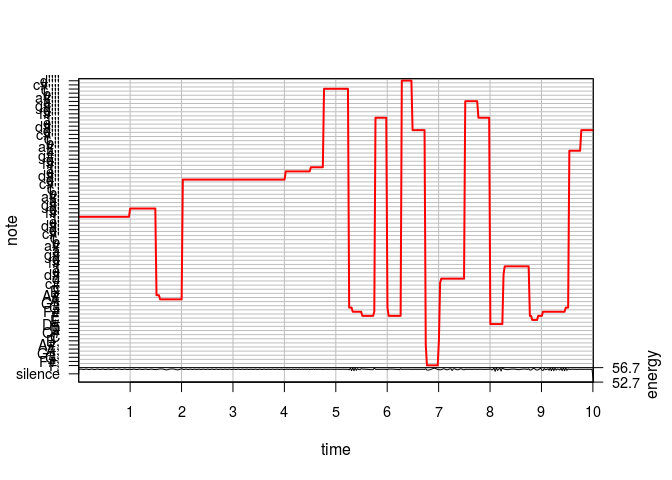

```r
sample2 <- generate_markov_sample(5, P2)
generate_lilypond(sample2, 5, file_name = here("results", "implement_consonance_ex2.ly"))
```

```r
p1 <- .01 #weight for sampling from two or more octaves below
p2 <- 1 #weight for sampling from within 1 octaves
p3 <- 5 #weight for sampling from the same octave
P3 <- matrix(numeric(88), nrow = 88, ncol = 88)
for (i in 1:7){
   for(j in 1:7){
      if(j != i){
         if(abs(j-i) > 1){
            P3[unlist(octaves[i]), unlist(octaves[j])] <- p1  #weight for greater than one octave away
         }else{
            P3[unlist(octaves[i]), unlist(octaves[j])] <- p2 #weight for one octave away
         }
      }else{
         P3[unlist(octaves[i]), unlist(octaves[i])] <- p3 #weight for the same octave
      }
   }
}

#the following ensures that the row sums are equal to 1
sums <- rowSums(P3)
P3[sums != 0, ] <- P3[sums != 0, ]/(sums[sums != 0])
rowSums(P3)
```

```
##  [1] 0 0 0 1 0 1 0 1 1 0 1 0 1 0 0 1 0 1 0 1 1 0 1 0 1 0 0 1 0 1 0 1 1 0 1
## [36] 0 1 0 0 1 0 1 0 1 1 0 1 0 1 0 0 1 0 1 0 1 1 0 1 0 1 0 0 1 0 1 0 1 1 0
## [71] 1 0 1 0 0 1 0 1 0 1 1 0 1 0 1 0 0 0
```

Generate the file:

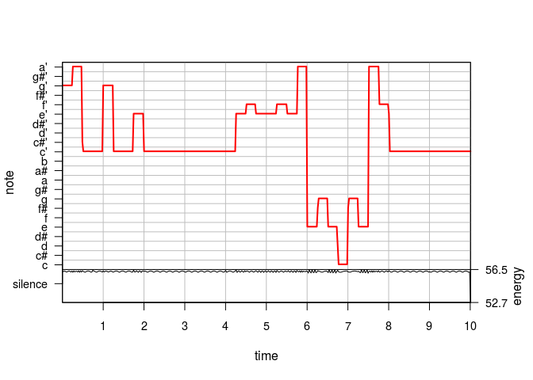

```r
sample3 <- generate_markov_sample(5, P3)
generate_lilypond(sample3, 5, file_name = here("results", "implement_consonance_ex3.ly"))
```

The notes appear to be closer together, which indiciates that there is less variation in which octaves the notes are contained in, so this implementation seems to be working. This example song can be found in the ‘results’ directory called ‘implement_consonance_ex3.ly’.

But ultimately, the best results were found by constricting each note to its own octave:

```r
P4 <- matrix(numeric(88), nrow = 88, ncol = 88)
for (i in 1:7){
         P4[unlist(octaves[i]), unlist(octaves[i])] <- 1/6
}

rowSums(P4) #check that the rows sums are 1
```

```
##  [1] 0 0 0 1 0 1 0 1 1 0 1 0 1 0 0 1 0 1 0 1 1 0 1 0 1 0 0 1 0 1 0 1 1 0 1
## [36] 0 1 0 0 1 0 1 0 1 1 0 1 0 1 0 0 1 0 1 0 1 1 0 1 0 1 0 0 1 0 1 0 1 1 0
## [71] 1 0 1 0 0 1 0 1 0 1 1 0 1 0 1 0 0 0
```

Generate a file:

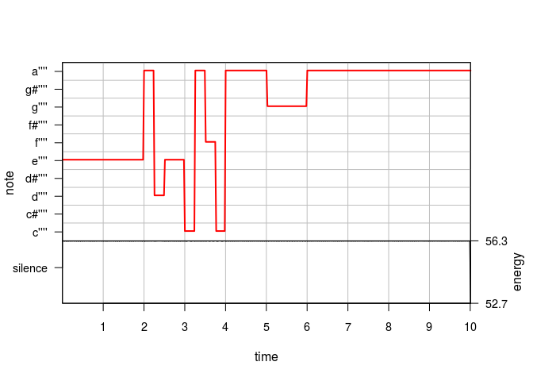

```r
sample4 <- generate_markov_sample(5, P4)
generate_lilypond(sample4, 5, file_name = here("results", "implement_consonance_ex4.ly"))
```

This makes sense, since introducing variation in pitch in a random way is not the best way to produce consonance. This example song can be found in the ‘results’ directory called ‘implement_consonance_ex4.ly’.